# ggplot2 그래프

#### (3단계) 설정 추가

마지막으로 축의 범위나 색, 표식 등의 세부 설정을 지정한다. 여기서는 x축은 3~6까지 표현하고 y축은 10~30까지 표현하자.

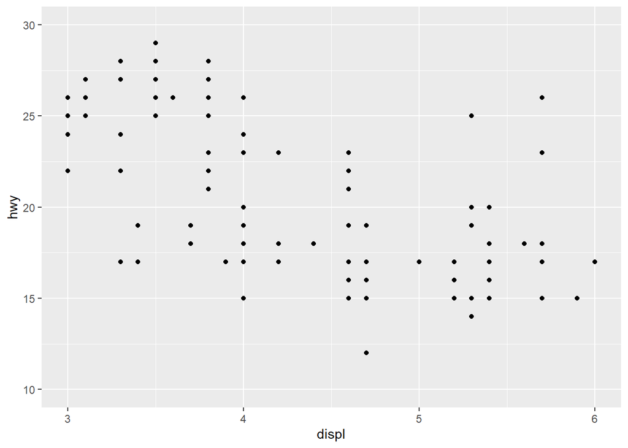

```r
ggplot(data = mpg, aes(x = displ, y = hwy)) +
  geom_point() + xlim(3, 6) + ylim(10, 30)
```

xlim(), yxlim()은 설정 역역을 벗어난 데이터포인트 삭제되어 추세선을 추가하면 결과가 왜곡되지만, **coord_cartesian()** 를 사용하면 데이터포인트를 삭제하지 않고 차트의 특정영역만 확대하여 나타낸다.

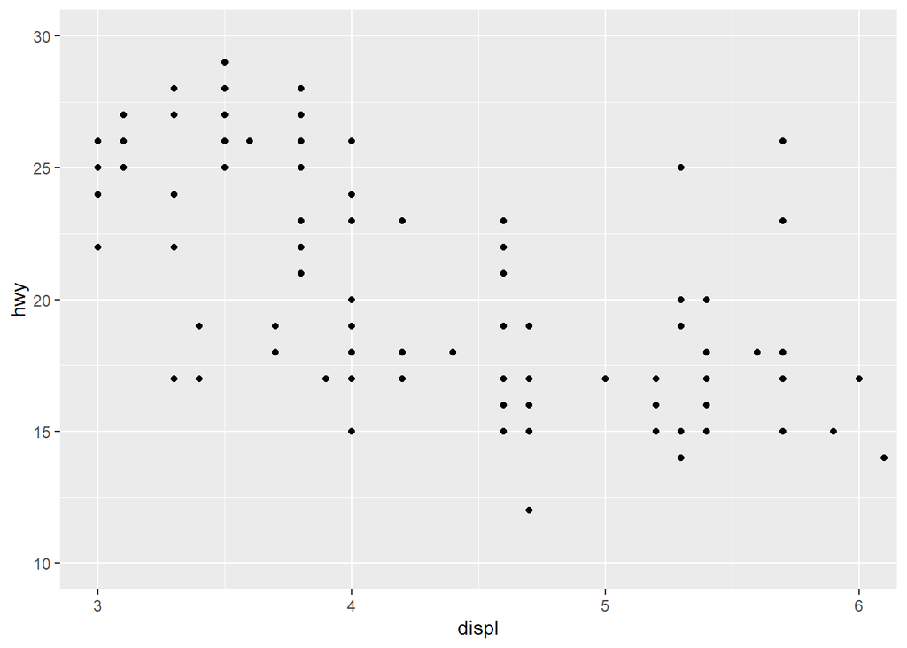

```r
ggplot(data=mpg, aes(x = displ, y = hwy)) +
  geom_point() + coord_cartesian(xlim=c(3, 6), ylim=c(10, 30))
```

ggplot2를 이용하여 쉽고 짧은 문법으로 보기좋은 그래프를 작성할 수 있다.

### 미적요소 및 추세선 추가

좀더 보기좋게 아래 코드와 같이 산점도 표식의 크기와 색을 지정할 수도 있다.

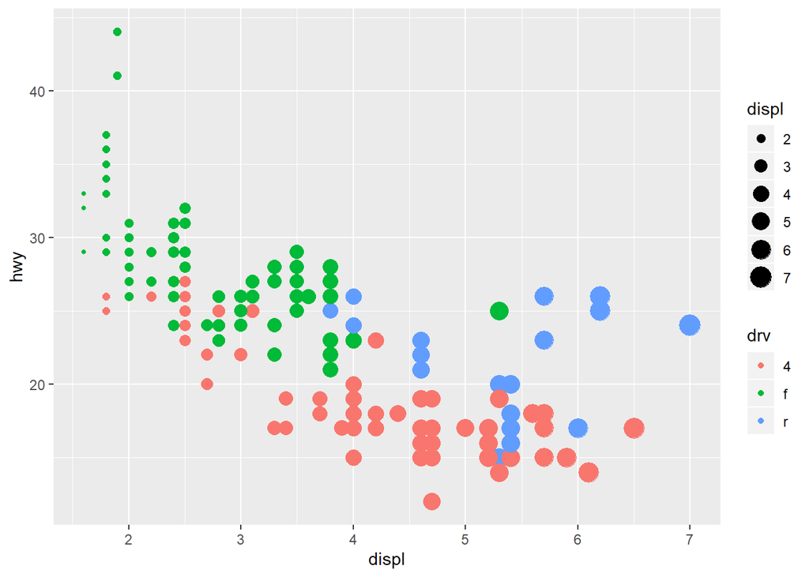

```r
ggplot(data = mpg, aes(x = displ, y = hwy)) +
  geom_point(aes(color=drv, size=displ))
```

산점도 위에 추세선을 추가하면 값의 흐름이 어떠한지 경향을 파악할 수 있다.

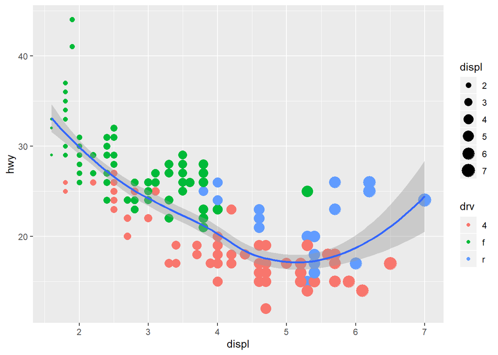

```r
ggplot(data = mpg, aes(x = displ, y = hwy)) +
  geom_point(aes(color=drv, size=displ)) +
 stat_smooth()
```

ggplot2에서는 추세선을 그릴 때 국소회귀분석(loess) 방식을 사용하기 때문에 위의 그래프와 같이 부드러운 추세선이 나타난다. 직선 형태의 추세선을 그리려면 **stat_smooth(method=‘lm’)** 을 사용하여 선형회귀분석(lm) 방식으로 그린다.

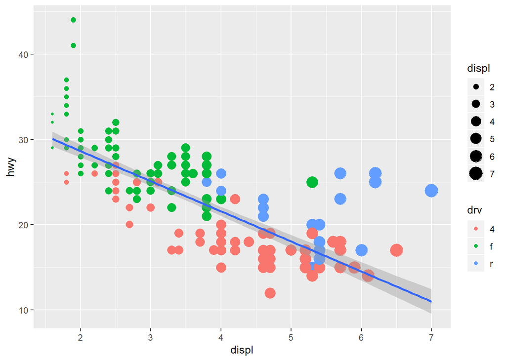

```r
ggplot(data = mpg, aes(x = displ, y = hwy)) +
  geom_point(aes(color=drv, size=displ)) +
  stat_smooth(method='lm')
```

산점도와 추세선을 통해 배기량(displ)이 늘어날수록 고속도로연비(hwy)가 줄어드는 경향이 있음을 한눈에 파악할 수 있다

## 상관분석

#### 상관계수

위의 그래프에서 관측값들의 분포가 추세선 가까운 것을 확인할 수 있다. 상관계수는 선형성의 정도를 나타내는 척도로서 -1과 1 사이의 값이다. 1이나 -1에 가까울 수록 두 변수 간의 상관성이 높은 것이다. 일반적으로 상관계수가 0.5보다 크거나 -0.5보다 작으면 상관성이 높다고 판단한다.

```r
cor(mpg$displ, mpg$hwy)
```

```
## [1] -0.76602
```

배기량(displ)과 고속도로연비(hwy)의 상관계수가 -0.76602이므로 두 변수 간의 상관성이 높다고 할 수 있다.

#### 회귀식

```r
lm( mpg$hwy~mpg$displ)
```

```
##
## Call:
## lm(formula = mpg$hwy ~ mpg$displ)
##
## Coefficients:
## (Intercept)    mpg$displ
##      35.698       -3.531
```

위의 결과를 통해 회귀식이 다음과 같음을 알 수 있다.

$y = -3.531x + 35.698$

배기량(displ)이 $x$에 해당하고 고속도로연비(hwy)가 $y$에 해당하므로, 배기량이 8, 9, 10인 자동차의 고속도로연비가 7.45, 3.919, 0.388 될 것이라고 예측할 수 있다.

```r
(y <- -3.531*8 + 35.698)
```

```
## [1] 7.45
```

```r
(y <- -3.531*9 + 35.698)
```

```
## [1] 3.919
```

```r
(y <- -3.531*10 + 35.698)
```

```
## [1] 0.388
```

### ggplot 그래프 저장

ggplot 그래프는 ggsave()를 사용하여 그림 파일로 저장할 수 있다.

```r
gpt <- ggplot(mpg, aes(x=cyl)) + geom_bar()

ggsave("myggplot.png")            # 마지막에 작성한 그래프를 파일에 저장
ggsave("myggplot.png", plot=gpt)  # gpt 변수에 저장해둔 그래프를 파일에 저장
```

# 막대 그래프(Bar Chart)

막대그래프는 데이터의 크기를 막대의 길이로 표현한 그래프로서 성별이나 소득의 차이처럼 집단 간 차이를 표현할 때 주로 사용한다.

## 차종별 빈도그래프

자동차 종류(class)별 빈도 즉, 값의 갯수를 막대그래프로 그려보자. 먼저, 빈도표를 통해 차종별로 자동차 대수를 살펴보면 다음과 같다.

```r
table(mpg$class)
```

```
##
##    2seater    compact    midsize    minivan     pickup subcompact
##          5         47         41         11         33         35
##        suv
##         62
```

#### (방법1) qplot() 사용

앞에서 배웠던 **qplot()**을 사용하여 차종(class)별 빈도그래프를 그려보자.

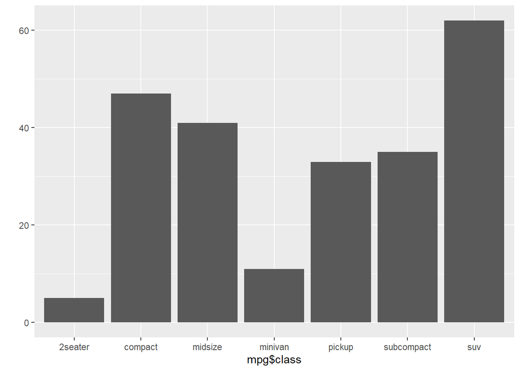

```r
qplot(mpg$class)
```